# Risk Factor Analysis

## Outcome Variable

**Outcome Variable:** haz

## Predictor Variables

**Intervention Variable:** anywast06

**Adjustment Set:**

- arm
- sex
- W_mage
- meducyrs
- month
- brthmon
- delta_W_mage
- delta_meducyrs
- delta_month
- delta_brthmon

## Stratifying Variables

The analysis was stratified on these variable(s):

- agecat
- studyid
- country

## Data Summary

| agecat | studyid | country | anywast06 | n_cell | n |
| --- | --- | --- | --- | --- | --- |
| Birth | ki0047075b-MAL-ED | BANGLADESH | 0 | 198 | 255 |
| Birth | ki0047075b-MAL-ED | BANGLADESH | 1 | 57 | 255 |
| Birth | ki0047075b-MAL-ED | BRAZIL | 0 | 178 | 191 |
| Birth | ki0047075b-MAL-ED | BRAZIL | 1 | 13 | 191 |
| Birth | ki0047075b-MAL-ED | INDIA | 0 | 144 | 206 |
| Birth | ki0047075b-MAL-ED | INDIA | 1 | 62 | 206 |
| Birth | ki0047075b-MAL-ED | NEPAL | 0 | 141 | 173 |
| Birth | ki0047075b-MAL-ED | NEPAL | 1 | 32 | 173 |
| Birth | ki0047075b-MAL-ED | PERU | 0 | 275 | 286 |
| Birth | ki0047075b-MAL-ED | PERU | 1 | 11 | 286 |
| Birth | ki0047075b-MAL-ED | SOUTH AFRICA | 0 | 230 | 261 |
| Birth | ki0047075b-MAL-ED | SOUTH AFRICA | 1 | 31 | 261 |
| Birth | ki0047075b-MAL-ED | TANZANIA, UNITED REPUBLIC OF | 0 | 117 | 123 |
| Birth | ki0047075b-MAL-ED | TANZANIA, UNITED REPUBLIC OF | 1 | 6 | 123 |
| Birth | ki1000108-CMC-V-BCS-2002 | INDIA | 0 | 36 | 90 |
| Birth | ki1000108-CMC-V-BCS-2002 | INDIA | 1 | 54 | 90 |
| Birth | ki1000108-IRC | INDIA | 0 | 164 | 388 |
| Birth | ki1000108-IRC | INDIA | 1 | 224 | 388 |
| Birth | ki1000109-EE | PAKISTAN | 0 | 0 | 2 |
| Birth | ki1000109-EE | PAKISTAN | 1 | 2 | 2 |
| Birth | ki1000109-ResPak | PAKISTAN | 0 | 6 | 7 |
| Birth | ki1000109-ResPak | PAKISTAN | 1 | 1 | 7 |
| Birth | ki1101329-Keneba | GAMBIA | 0 | 1287 | 1541 |
| Birth | ki1101329-Keneba | GAMBIA | 1 | 254 | 1541 |
| Birth | ki1114097-CMIN | BANGLADESH | 0 | 5 | 8 |
| Birth | ki1114097-CMIN | BANGLADESH | 1 | 3 | 8 |
| Birth | ki1114097-CMIN | PERU | 0 | 10 | 10 |
| Birth | ki1114097-CMIN | PERU | 1 | 0 | 10 |
| Birth | ki1114097-CONTENT | PERU | 0 | 2 | 2 |
| Birth | ki1114097-CONTENT | PERU | 1 | 0 | 2 |

[output cut: 70 more lines]

The following strata were considered:

- agecat: 24 months, studyid: ki0047075b-MAL-ED, country: BANGLADESH
- agecat: 24 months, studyid: ki0047075b-MAL-ED, country: BRAZIL
- agecat: 24 months, studyid: ki0047075b-MAL-ED, country: INDIA
- agecat: 24 months, studyid: ki0047075b-MAL-ED, country: NEPAL
- agecat: 24 months, studyid: ki0047075b-MAL-ED, country: PERU
- agecat: 24 months, studyid: ki0047075b-MAL-ED, country: SOUTH AFRICA
- agecat: 24 months, studyid: ki0047075b-MAL-ED, country: TANZANIA, UNITED REPUBLIC OF
- agecat: 24 months, studyid: ki1000108-CMC-V-BCS-2002, country: INDIA
- agecat: 24 months, studyid: ki1000108-IRC, country: INDIA
- agecat: 24 months, studyid: ki1017093b-PROVIDE, country: BANGLADESH
- agecat: 24 months, studyid: ki1066203-TanzaniaChild2, country: TANZANIA, UNITED REPUBLIC OF
- agecat: 24 months, studyid: ki1101329-Keneba, country: GAMBIA
- agecat: 24 months, studyid: ki1113344-GMS-Nepal, country: NEPAL
- agecat: 24 months, studyid: ki1114097-CMIN, country: BANGLADESH
- agecat: 24 months, studyid: ki1114097-CMIN, country: PERU
- agecat: 24 months, studyid: ki1114097-CONTENT, country: PERU
- agecat: 6 months, studyid: ki0047075b-MAL-ED, country: BANGLADESH
- agecat: 6 months, studyid: ki0047075b-MAL-ED, country: BRAZIL
- agecat: 6 months, studyid: ki0047075b-MAL-ED, country: INDIA
- agecat: 6 months, studyid: ki0047075b-MAL-ED, country: NEPAL
- agecat: 6 months, studyid: ki0047075b-MAL-ED, country: PERU
- agecat: 6 months, studyid: ki0047075b-MAL-ED, country: SOUTH AFRICA
- agecat: 6 months, studyid: ki0047075b-MAL-ED, country: TANZANIA, UNITED REPUBLIC OF
- agecat: 6 months, studyid: ki1000108-CMC-V-BCS-2002, country: INDIA
- agecat: 6 months, studyid: ki1000108-IRC, country: INDIA
- agecat: 6 months, studyid: ki1000109-EE, country: PAKISTAN
- agecat: 6 months, studyid: ki1000109-ResPak, country: PAKISTAN
- agecat: 6 months, studyid: ki1017093b-PROVIDE, country: BANGLADESH
- agecat: 6 months, studyid: ki1066203-TanzaniaChild2, country: TANZANIA, UNITED REPUBLIC OF
- agecat: 6 months, studyid: ki1101329-Keneba, country: GAMBIA
- agecat: 6 months, studyid: ki1112895-Guatemala BSC, country: GUATEMALA
- agecat: 6 months, studyid: ki1113344-GMS-Nepal, country: NEPAL
- agecat: 6 months, studyid: ki1114097-CMIN, country: BANGLADESH
- agecat: 6 months, studyid: ki1114097-CMIN, country: PERU
- agecat: 6 months, studyid: ki1114097-CONTENT, country: PERU
- agecat: Birth, studyid: ki0047075b-MAL-ED, country: BANGLADESH
- agecat: Birth, studyid: ki0047075b-MAL-ED, country: BRAZIL
- agecat: Birth, studyid: ki0047075b-MAL-ED, country: INDIA
- agecat: Birth, studyid: ki0047075b-MAL-ED, country: NEPAL
- agecat: Birth, studyid: ki0047075b-MAL-ED, country: PERU
- agecat: Birth, studyid: ki0047075b-MAL-ED, country: SOUTH AFRICA
- agecat: Birth, studyid: ki0047075b-MAL-ED, country: TANZANIA, UNITED REPUBLIC OF
- agecat: Birth, studyid: ki1000108-CMC-V-BCS-2002, country: INDIA
- agecat: Birth, studyid: ki1000108-IRC, country: INDIA
- agecat: Birth, studyid: ki1000109-EE, country: PAKISTAN
- agecat: Birth, studyid: ki1000109-ResPak, country: PAKISTAN
- agecat: Birth, studyid: ki1101329-Keneba, country: GAMBIA
- agecat: Birth, studyid: ki1114097-CMIN, country: BANGLADESH
- agecat: Birth, studyid: ki1114097-CMIN, country: PERU
- agecat: Birth, studyid: ki1114097-CONTENT, country: PERU

### Dropped Strata

Some strata were dropped due to rare outcomes:

- agecat: Birth, studyid: ki1000109-EE, country: PAKISTAN
- agecat: Birth, studyid: ki1000109-ResPak, country: PAKISTAN
- agecat: Birth, studyid: ki1114097-CMIN, country: BANGLADESH
- agecat: Birth, studyid: ki1114097-CMIN, country: PERU
- agecat: Birth, studyid: ki1114097-CONTENT, country: PERU
- agecat: 6 months, studyid: ki1114097-CONTENT, country: PERU
- agecat: 24 months, studyid: ki1066203-TanzaniaChild2, country: TANZANIA, UNITED REPUBLIC OF
- agecat: 24 months, studyid: ki1114097-CONTENT, country: PERU

## Methods Detail

We’re interested in the causal parameters $E[Y_a]$ for all values of $a \in \mathcal{A}$. These parameters represent the mean outcome if, possibly contrary to fact, we intervened to set all units to have $A=a$. Under the randomization and positivity assumptions, these are identified by the statistical parameters $\psi_a=E_W[E_{Y|A,W}(Y|A=a,W)]$. In addition, we’re interested in the mean of $Y$, $E[Y]$ under no intervention (the observed mean). We will estimate these parameters by using SuperLearner to fit the relevant likelihood factors – $E_{Y|A,W}(Y|A=a,W)$ and $p(A=a|W)$, and then updating our likelihood fit using a joint TMLE.

For unadjusted analyses ($W=\{\}$), initial likelihoods were estimated using Lrnr_glm to estimate the simple $E(Y|A)$ and Lrnr_mean to estimate $p(A)$. For adjusted analyses, a small library containing Lrnr_glmnet, Lrnr_xgboost, and Lrnr_mean was used.

Having estimated these parameters, we will then use the delta method to estimate relative risks and attributable risks relative to a prespecified baseline level of $A$.

# Results Detail

## Results Plots

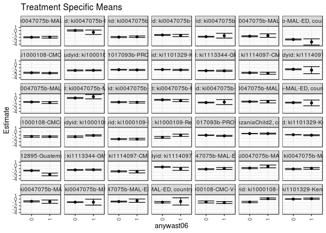

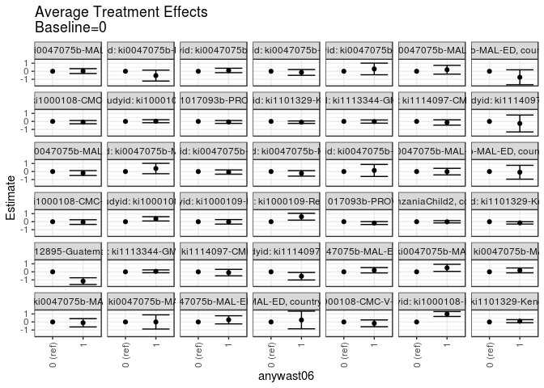

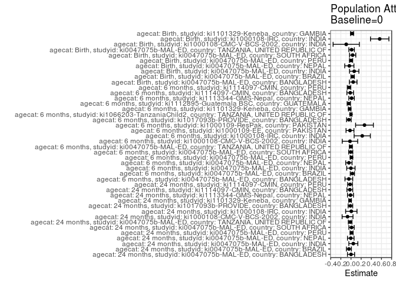

## Results Table

### Parameter: TSM

| agecat | studyid | country | intervention_level | baseline_level | estimate | ci_lower | ci_upper |
| --- | --- | --- | --- | --- | --- | --- | --- |
| Birth | ki0047075b-MAL-ED | BANGLADESH | 0 | NA | -1.1149797 | -1.2537136 | -0.9762458 |
| Birth | ki0047075b-MAL-ED | BANGLADESH | 1 | NA | -0.9176308 | -1.2200770 | -0.6151847 |
| Birth | ki0047075b-MAL-ED | BRAZIL | 0 | NA | -0.7933950 | -0.9582670 | -0.6285230 |
| Birth | ki0047075b-MAL-ED | BRAZIL | 1 | NA | -0.2995157 | -0.7100852 | 0.1110538 |
| Birth | ki0047075b-MAL-ED | INDIA | 0 | NA | -1.0735631 | -1.2406120 | -0.9065143 |
| Birth | ki0047075b-MAL-ED | INDIA | 1 | NA | -0.8950863 | -1.1484156 | -0.6417570 |
| Birth | ki0047075b-MAL-ED | NEPAL | 0 | NA | -0.6758511 | -0.8409709 | -0.5107313 |
| Birth | ki0047075b-MAL-ED | NEPAL | 1 | NA | -0.7796831 | -1.2684180 | -0.2909481 |
| Birth | ki0047075b-MAL-ED | PERU | 0 | NA | -0.9175513 | -1.0272169 | -0.8078856 |
| Birth | ki0047075b-MAL-ED | PERU | 1 | NA | -0.9144144 | -1.7899147 | -0.0389141 |
| Birth | ki0047075b-MAL-ED | SOUTH AFRICA | 0 | NA | -0.7388752 | -0.8589411 | -0.6188093 |
| Birth | ki0047075b-MAL-ED | SOUTH AFRICA | 1 | NA | -0.4712200 | -0.9636195 | 0.0211794 |
| Birth | ki0047075b-MAL-ED | TANZANIA, UNITED REPUBLIC OF | 0 | NA | -0.9458974 | -1.1623359 | -0.7294590 |
| Birth | ki0047075b-MAL-ED | TANZANIA, UNITED REPUBLIC OF | 1 | NA | -0.6983333 | -1.7751862 | 0.3785195 |
| Birth | ki1000108-CMC-V-BCS-2002 | INDIA | 0 | NA | -0.8714716 | -1.1821028 | -0.5608404 |
| Birth | ki1000108-CMC-V-BCS-2002 | INDIA | 1 | NA | -1.0455753 | -1.3336506 | -0.7575000 |
| Birth | ki1000108-IRC | INDIA | 0 | NA | -0.8731886 | -1.0831104 | -0.6632667 |
| Birth | ki1000108-IRC | INDIA | 1 | NA | 0.1180354 | -0.0990382 | 0.3351089 |
| Birth | ki1101329-Keneba | GAMBIA | 0 | NA | 0.0131278 | -0.0544511 | 0.0807066 |
| Birth | ki1101329-Keneba | GAMBIA | 1 | NA | 0.1057605 | -0.0743091 | 0.2858300 |
| 6 months | ki0047075b-MAL-ED | BANGLADESH | 0 | NA | -1.1633118 | -1.2892925 | -1.0373312 |
| 6 months | ki0047075b-MAL-ED | BANGLADESH | 1 | NA | -1.3476763 | -1.6245875 | -1.0707652 |
| 6 months | ki0047075b-MAL-ED | BRAZIL | 0 | NA | 0.0239572 | -0.1249050 | 0.1728194 |
| 6 months | ki0047075b-MAL-ED | BRAZIL | 1 | NA | 0.4026045 | -0.2270893 | 1.0322982 |
| 6 months | ki0047075b-MAL-ED | INDIA | 0 | NA | -1.2183179 | -1.3590573 | -1.0775785 |
| 6 months | ki0047075b-MAL-ED | INDIA | 1 | NA | -1.2803496 | -1.5022681 | -1.0584311 |
| 6 months | ki0047075b-MAL-ED | NEPAL | 0 | NA | -0.5197875 | -0.6381123 | -0.4014628 |
| 6 months | ki0047075b-MAL-ED | NEPAL | 1 | NA | -0.7462267 | -1.0672094 | -0.4252440 |
| 6 months | ki0047075b-MAL-ED | PERU | 0 | NA | -1.3358387 | -1.4452212 | -1.2264563 |
| 6 months | ki0047075b-MAL-ED | PERU | 1 | NA | -1.1967371 | -1.9388162 | -0.4546579 |

[output cut: 54 more lines]

### Parameter: E(Y)

| agecat | studyid | country | intervention_level | baseline_level | estimate | ci_lower | ci_upper |
| --- | --- | --- | --- | --- | --- | --- | --- |
| Birth | ki0047075b-MAL-ED | BANGLADESH | NA | NA | -1.0715686 | -1.1969582 | -0.9461791 |
| Birth | ki0047075b-MAL-ED | BRAZIL | NA | NA | -0.7609424 | -0.9178311 | -0.6040538 |
| Birth | ki0047075b-MAL-ED | INDIA | NA | NA | -1.0106311 | -1.1499962 | -0.8712660 |
| Birth | ki0047075b-MAL-ED | NEPAL | NA | NA | -0.7089017 | -0.8656064 | -0.5521971 |
| Birth | ki0047075b-MAL-ED | PERU | NA | NA | -0.9163986 | -1.0263706 | -0.8064266 |
| Birth | ki0047075b-MAL-ED | SOUTH AFRICA | NA | NA | -0.7064368 | -0.8290380 | -0.5838355 |
| Birth | ki0047075b-MAL-ED | TANZANIA, UNITED REPUBLIC OF | NA | NA | -0.9338211 | -1.1465079 | -0.7211344 |
| Birth | ki1000108-CMC-V-BCS-2002 | INDIA | NA | NA | -0.9654444 | -1.1742112 | -0.7566777 |
| Birth | ki1000108-IRC | INDIA | NA | NA | -0.3080412 | -0.4687931 | -0.1472894 |
| Birth | ki1101329-Keneba | GAMBIA | NA | NA | 0.0341467 | -0.0293905 | 0.0976838 |
| 6 months | ki0047075b-MAL-ED | BANGLADESH | NA | NA | -1.2056777 | -1.3231497 | -1.0882058 |
| 6 months | ki0047075b-MAL-ED | BRAZIL | NA | NA | 0.0510207 | -0.0930194 | 0.1950608 |
| 6 months | ki0047075b-MAL-ED | INDIA | NA | NA | -1.2203672 | -1.3387619 | -1.1019726 |
| 6 months | ki0047075b-MAL-ED | NEPAL | NA | NA | -0.5610593 | -0.6737915 | -0.4483272 |
| 6 months | ki0047075b-MAL-ED | PERU | NA | NA | -1.3268010 | -1.4351217 | -1.2184802 |
| 6 months | ki0047075b-MAL-ED | SOUTH AFRICA | NA | NA | -1.0633760 | -1.1911088 | -0.9356432 |
| 6 months | ki0047075b-MAL-ED | TANZANIA, UNITED REPUBLIC OF | NA | NA | -1.3601215 | -1.4821830 | -1.2380600 |
| 6 months | ki1000108-CMC-V-BCS-2002 | INDIA | NA | NA | -1.4251321 | -1.5673802 | -1.2828839 |
| 6 months | ki1000108-IRC | INDIA | NA | NA | -1.2344062 | -1.3658524 | -1.1029600 |
| 6 months | ki1000109-EE | PAKISTAN | NA | NA | -2.2004704 | -2.3234073 | -2.0775336 |
| 6 months | ki1000109-ResPak | PAKISTAN | NA | NA | -1.4029220 | -1.6085859 | -1.1972581 |
| 6 months | ki1017093b-PROVIDE | BANGLADESH | NA | NA | -1.0871041 | -1.1635539 | -1.0106543 |
| 6 months | ki1066203-TanzaniaChild2 | TANZANIA, UNITED REPUBLIC OF | NA | NA | -0.5434389 | -0.5924056 | -0.4944722 |
| 6 months | ki1101329-Keneba | GAMBIA | NA | NA | -0.9121372 | -0.9593127 | -0.8649617 |
| 6 months | ki1112895-Guatemala BSC | GUATEMALA | NA | NA | -1.5785476 | -1.6926664 | -1.4644288 |
| 6 months | ki1113344-GMS-Nepal | NEPAL | NA | NA | -1.3321522 | -1.4103691 | -1.2539352 |
| 6 months | ki1114097-CMIN | BANGLADESH | NA | NA | -1.7844376 | -1.9222926 | -1.6465825 |
| 6 months | ki1114097-CMIN | PERU | NA | NA | -0.5098299 | -0.5892202 | -0.4304395 |
| 24 months | ki0047075b-MAL-ED | BANGLADESH | NA | NA | -1.9431132 | -2.0691678 | -1.8170586 |
| 24 months | ki0047075b-MAL-ED | BRAZIL | NA | NA | 0.0418343 | -0.1253834 | 0.2090521 |
| 24 months | ki0047075b-MAL-ED | INDIA | NA | NA | -1.8458150 | -1.9718703 | -1.7197596 |
| 24 months | ki0047075b-MAL-ED | NEPAL | NA | NA | -1.2752193 | -1.3954783 | -1.1549603 |
| 24 months | ki0047075b-MAL-ED | PERU | NA | NA | -1.7500995 | -1.8705474 | -1.6296516 |
| 24 months | ki0047075b-MAL-ED | SOUTH AFRICA | NA | NA | -1.6228361 | -1.7581177 | -1.4875546 |
| 24 months | ki0047075b-MAL-ED | TANZANIA, UNITED REPUBLIC OF | NA | NA | -2.6058879 | -2.7403043 | -2.4714714 |
| 24 months | ki1000108-CMC-V-BCS-2002 | INDIA | NA | NA | -2.5530299 | -2.6529925 | -2.4530672 |
| 24 months | ki1000108-IRC | INDIA | NA | NA | -1.7824776 | -1.8765600 | -1.6883952 |
| 24 months | ki1017093b-PROVIDE | BANGLADESH | NA | NA | -1.5861179 | -1.6693668 | -1.5028689 |
| 24 months | ki1101329-Keneba | GAMBIA | NA | NA | -1.5604961 | -1.6126979 | -1.5082943 |
| 24 months | ki1113344-GMS-Nepal | NEPAL | NA | NA | -1.8835905 | -1.9681499 | -1.7990312 |
| 24 months | ki1114097-CMIN | BANGLADESH | NA | NA | -2.5109504 | -2.6361514 | -2.3857494 |
| 24 months | ki1114097-CMIN | PERU | NA | NA | -1.4696439 | -1.5956384 | -1.3436493 |

### Parameter: ATE

| agecat | studyid | country | intervention_level | baseline_level | estimate | ci_lower | ci_upper |
| --- | --- | --- | --- | --- | --- | --- | --- |
| Birth | ki0047075b-MAL-ED | BANGLADESH | 0 | 0 | 0.0000000 | 0.0000000 | 0.0000000 |
| Birth | ki0047075b-MAL-ED | BANGLADESH | 1 | 0 | 0.1973489 | -0.1360839 | 0.5307816 |
| Birth | ki0047075b-MAL-ED | BRAZIL | 0 | 0 | 0.0000000 | 0.0000000 | 0.0000000 |
| Birth | ki0047075b-MAL-ED | BRAZIL | 1 | 0 | 0.4938793 | 0.0509541 | 0.9368045 |
| Birth | ki0047075b-MAL-ED | INDIA | 0 | 0 | 0.0000000 | 0.0000000 | 0.0000000 |
| Birth | ki0047075b-MAL-ED | INDIA | 1 | 0 | 0.1784768 | -0.1257197 | 0.4826733 |
| Birth | ki0047075b-MAL-ED | NEPAL | 0 | 0 | 0.0000000 | 0.0000000 | 0.0000000 |
| Birth | ki0047075b-MAL-ED | NEPAL | 1 | 0 | -0.1038320 | -0.6205613 | 0.4128973 |
| Birth | ki0047075b-MAL-ED | PERU | 0 | 0 | 0.0000000 | 0.0000000 | 0.0000000 |
| Birth | ki0047075b-MAL-ED | PERU | 1 | 0 | 0.0031368 | -0.8793533 | 0.8856270 |
| Birth | ki0047075b-MAL-ED | SOUTH AFRICA | 0 | 0 | 0.0000000 | 0.0000000 | 0.0000000 |
| Birth | ki0047075b-MAL-ED | SOUTH AFRICA | 1 | 0 | 0.2676552 | -0.2387281 | 0.7740384 |
| Birth | ki0047075b-MAL-ED | TANZANIA, UNITED REPUBLIC OF | 0 | 0 | 0.0000000 | 0.0000000 | 0.0000000 |
| Birth | ki0047075b-MAL-ED | TANZANIA, UNITED REPUBLIC OF | 1 | 0 | 0.2475641 | -0.8508246 | 1.3459528 |
| Birth | ki1000108-CMC-V-BCS-2002 | INDIA | 0 | 0 | 0.0000000 | 0.0000000 | 0.0000000 |
| Birth | ki1000108-CMC-V-BCS-2002 | INDIA | 1 | 0 | -0.1741037 | -0.6010272 | 0.2528198 |
| Birth | ki1000108-IRC | INDIA | 0 | 0 | 0.0000000 | 0.0000000 | 0.0000000 |
| Birth | ki1000108-IRC | INDIA | 1 | 0 | 0.9912239 | 0.6880584 | 1.2943894 |
| Birth | ki1101329-Keneba | GAMBIA | 0 | 0 | 0.0000000 | 0.0000000 | 0.0000000 |
| Birth | ki1101329-Keneba | GAMBIA | 1 | 0 | 0.0926327 | -0.0995962 | 0.2848616 |
| 6 months | ki0047075b-MAL-ED | BANGLADESH | 0 | 0 | 0.0000000 | 0.0000000 | 0.0000000 |
| 6 months | ki0047075b-MAL-ED | BANGLADESH | 1 | 0 | -0.1843645 | -0.4889348 | 0.1202057 |
| 6 months | ki0047075b-MAL-ED | BRAZIL | 0 | 0 | 0.0000000 | 0.0000000 | 0.0000000 |
| 6 months | ki0047075b-MAL-ED | BRAZIL | 1 | 0 | 0.3786473 | -0.2680956 | 1.0253901 |
| 6 months | ki0047075b-MAL-ED | INDIA | 0 | 0 | 0.0000000 | 0.0000000 | 0.0000000 |
| 6 months | ki0047075b-MAL-ED | INDIA | 1 | 0 | -0.0620317 | -0.3265954 | 0.2025320 |
| 6 months | ki0047075b-MAL-ED | NEPAL | 0 | 0 | 0.0000000 | 0.0000000 | 0.0000000 |
| 6 months | ki0047075b-MAL-ED | NEPAL | 1 | 0 | -0.2264392 | -0.5692853 | 0.1164070 |
| 6 months | ki0047075b-MAL-ED | PERU | 0 | 0 | 0.0000000 | 0.0000000 | 0.0000000 |
| 6 months | ki0047075b-MAL-ED | PERU | 1 | 0 | 0.1391017 | -0.6107957 | 0.8889991 |

[output cut: 54 more lines]

### Parameter: PAR

| agecat | studyid | country | intervention_level | baseline_level | estimate | ci_lower | ci_upper |
| --- | --- | --- | --- | --- | --- | --- | --- |
| Birth | ki0047075b-MAL-ED | BANGLADESH | 0 | NA | 0.0434111 | -0.0316489 | 0.1184711 |
| Birth | ki0047075b-MAL-ED | BRAZIL | 0 | NA | 0.0324526 | -0.0013474 | 0.0662526 |
| Birth | ki0047075b-MAL-ED | INDIA | 0 | NA | 0.0629320 | -0.0291926 | 0.1550567 |
| Birth | ki0047075b-MAL-ED | NEPAL | 0 | NA | -0.0330506 | -0.1238686 | 0.0577673 |
| Birth | ki0047075b-MAL-ED | PERU | 0 | NA | 0.0011527 | -0.0305691 | 0.0328744 |
| Birth | ki0047075b-MAL-ED | SOUTH AFRICA | 0 | NA | 0.0324384 | -0.0289593 | 0.0938362 |
| Birth | ki0047075b-MAL-ED | TANZANIA, UNITED REPUBLIC OF | 0 | NA | 0.0120763 | -0.0423328 | 0.0664854 |
| Birth | ki1000108-CMC-V-BCS-2002 | INDIA | 0 | NA | -0.0939729 | -0.3525288 | 0.1645831 |
| Birth | ki1000108-IRC | INDIA | 0 | NA | 0.5651473 | 0.3837538 | 0.7465408 |
| Birth | ki1101329-Keneba | GAMBIA | 0 | NA | 0.0210189 | -0.0101821 | 0.0522198 |
| 6 months | ki0047075b-MAL-ED | BANGLADESH | 0 | NA | -0.0423659 | -0.1186978 | 0.0339659 |
| 6 months | ki0047075b-MAL-ED | BRAZIL | 0 | NA | 0.0270635 | -0.0145419 | 0.0686689 |
| 6 months | ki0047075b-MAL-ED | INDIA | 0 | NA | -0.0020493 | -0.0838978 | 0.0797991 |
| 6 months | ki0047075b-MAL-ED | NEPAL | 0 | NA | -0.0412718 | -0.1034676 | 0.0209240 |
| 6 months | ki0047075b-MAL-ED | PERU | 0 | NA | 0.0090378 | -0.0166909 | 0.0347665 |
| 6 months | ki0047075b-MAL-ED | SOUTH AFRICA | 0 | NA | -0.0055162 | -0.0460219 | 0.0349894 |
| 6 months | ki0047075b-MAL-ED | TANZANIA, UNITED REPUBLIC OF | 0 | NA | -0.0022828 | -0.0319568 | 0.0273912 |
| 6 months | ki1000108-CMC-V-BCS-2002 | INDIA | 0 | NA | -0.0203846 | -0.1727741 | 0.1320048 |
| 6 months | ki1000108-IRC | INDIA | 0 | NA | 0.2213793 | 0.0616075 | 0.3811511 |
| 6 months | ki1000109-EE | PAKISTAN | 0 | NA | -0.0200296 | -0.0980506 | 0.0579914 |
| 6 months | ki1000109-ResPak | PAKISTAN | 0 | NA | 0.2654608 | 0.0902900 | 0.4406316 |
| 6 months | ki1017093b-PROVIDE | BANGLADESH | 0 | NA | -0.0418316 | -0.0875054 | 0.0038421 |
| 6 months | ki1066203-TanzaniaChild2 | TANZANIA, UNITED REPUBLIC OF | 0 | NA | -0.0008716 | -0.0216529 | 0.0199097 |
| 6 months | ki1101329-Keneba | GAMBIA | 0 | NA | -0.0259773 | -0.0515674 | -0.0003872 |
| 6 months | ki1112895-Guatemala BSC | GUATEMALA | 0 | NA | -0.0431684 | -0.0756907 | -0.0106461 |
| 6 months | ki1113344-GMS-Nepal | NEPAL | 0 | NA | 0.0110187 | -0.0428870 | 0.0649243 |
| 6 months | ki1114097-CMIN | BANGLADESH | 0 | NA | -0.0154564 | -0.0808782 | 0.0499654 |
| 6 months | ki1114097-CMIN | PERU | 0 | NA | -0.0388489 | -0.0730338 | -0.0046640 |
| 24 months | ki0047075b-MAL-ED | BANGLADESH | 0 | NA | 0.0004895 | -0.0697780 | 0.0707571 |
| 24 months | ki0047075b-MAL-ED | BRAZIL | 0 | NA | -0.0408888 | -0.0903062 | 0.0085286 |
| 24 months | ki0047075b-MAL-ED | INDIA | 0 | NA | 0.0460204 | -0.0427015 | 0.1347424 |
| 24 months | ki0047075b-MAL-ED | NEPAL | 0 | NA | -0.0046382 | -0.0693498 | 0.0600734 |
| 24 months | ki0047075b-MAL-ED | PERU | 0 | NA | 0.0115326 | -0.0183359 | 0.0414011 |
| 24 months | ki0047075b-MAL-ED | SOUTH AFRICA | 0 | NA | 0.0106376 | -0.0417600 | 0.0630352 |
| 24 months | ki0047075b-MAL-ED | TANZANIA, UNITED REPUBLIC OF | 0 | NA | -0.0169198 | -0.0527780 | 0.0189384 |
| 24 months | ki1000108-CMC-V-BCS-2002 | INDIA | 0 | NA | -0.0679293 | -0.1749242 | 0.0390655 |
| 24 months | ki1000108-IRC | INDIA | 0 | NA | 0.0062658 | -0.1057569 | 0.1182884 |
| 24 months | ki1017093b-PROVIDE | BANGLADESH | 0 | NA | -0.0115256 | -0.0566216 | 0.0335704 |
| 24 months | ki1101329-Keneba | GAMBIA | 0 | NA | -0.0176143 | -0.0438581 | 0.0086294 |
| 24 months | ki1113344-GMS-Nepal | NEPAL | 0 | NA | -0.0100142 | -0.0691774 | 0.0491489 |
| 24 months | ki1114097-CMIN | BANGLADESH | 0 | NA | -0.0229139 | -0.0796881 | 0.0338604 |
| 24 months | ki1114097-CMIN | PERU | 0 | NA | -0.0189031 | -0.0667209 | 0.0289148 |